# Regression and Other Stories: ChildCare

Andrew Gelman, Jennifer Hill, Aki Vehtari

2021-02-25

Code and figures for Infant Health and Development Program (IHDP) example. See Chapter 20 in Regression and Other Stories.

The intervention for low-birth-weight children is described by

- Brooks-Gunn, J., Liaw, F. R., and Klebanov, P. K. (1992). Effects of early intervention on cognitive function of low birth weight preterm infants. Journal of Pediatrics 120, 350–359.
- Hill, J. L., Brooks-Gunn, J., and Waldfogel, J. (2003). Sustained effects of high participation in an early intervention for low-birth-weight premature infants. Developmental Psychology 39, 730–744.

#### Load packages

```r
library("rprojroot")
root<-has_file(".ROS-Examples-root")$make_fix_file()
library("rstan")
library("arm")
library("rstanarm")
library("survey")
source(root("Childcare/library","matching.R"))
source(root("Childcare/library","balance.R"))
source(root("Childcare/library","estimation.R"))
```

#### Load data

```r
cc2 <- read.csv(root("Childcare/data","cc2.csv"))
head(cc2)
```

```
  momage momrace b.marr momed work.dur prenatal cig booze sex first   bw
1     33       3      1     4        1        1   0     0   1     0 1559
2     22       1      0     1        0        1   0     1   1     0 2240
3     13       1      0     1        0        1   0     0   1     1 1900
4     25       1      1     4        1        1   0     0   1     1 1550
5     19       1      0     1        0        1   1     0   1     0 2270
6     19       1      0     2        1        1   1     1   0     1 1550
  preterm      age dayskidh ppvtr.36 sample b.state st5 st9 st12 st25 st36 st42
1      10 60.79671       31      111      I       5   1   0    0    0    0    0
2       3 59.77823        4       81      I       5   1   0    0    0    0    0
3       6 59.51540        9       92      I       5   1   0    0    0    0    0
4       8 59.18686       50      103      I       5   1   0    0    0    0    0
5       5 58.79261        4       81      I       5   1   0    0    0    0    0
6       4 58.49692       13       94      I       5   1   0    0    0    0    0
  st48 st53 income    ineeds unemp.rt  st99 treat treat0 b.8state black
```

[output cut: 27 more lines]

#### Figure: displays a scatter plot of birthweight versus test scores

at age 3 with observations displayed in different colors.

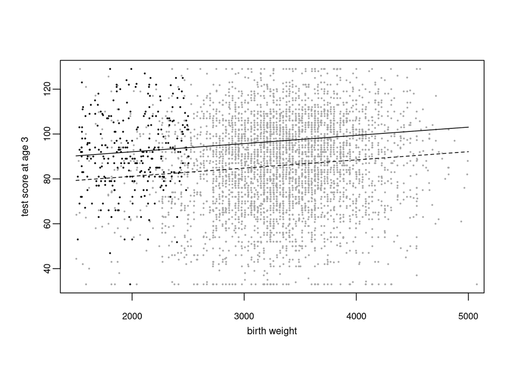

```r
par(mfrow=c(1,1))
tmp <- lm(ppvtr.36~bw+treat,data=cc2)$coef
plot(cc2$bw, cc2$ppvtr.36, xlab="birth weight", ylab="test score at age 3", mgp=c(2,.5,0), main="",type="n",xlim=c(1500,5000),cex.axis=.75,cex.lab=.8,lab=c(3,5,7),xaxt="n")
axis(side=1,at=c(2000,3000,4000,5000),cex.axis=.75)
points(cc2$bw[cc2$treat==0]+runif(sum(cc2$treat==0),-.5,5), cc2$ppvtr.36[cc2$treat==0], col="darkgrey", pch=20, cex=.3)
points(cc2$bw[cc2$treat==1]+runif(sum(cc2$treat==1),-.5,5), cc2$ppvtr.36[cc2$treat==1], pch=20, cex=.3)
curve(tmp[1]+tmp[2]*x,add=T,lty=2)
curve(tmp[1]+tmp[3]+tmp[2]*x,add=T)
```

## Plots

#### Figure: Overlap plot of mother’s education & age of child (months).

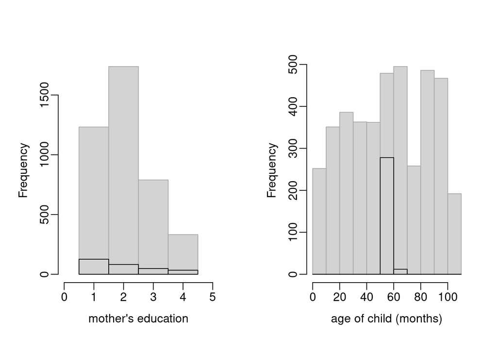

```r
par(mfrow=c(1,2))
hist(cc2$educ[cc2$treat==0],xlim=c(0,5),main="",border="darkgrey",breaks=c(.5,1.5,2.5,3.5,4.5),mgp=c(2,.5,0),xlab="mother's education",freq=TRUE)
hist(cc2$educ[cc2$treat==1],xlim=c(0,5),xlab="education",breaks=c(.5,1.5,2.5,3.5,4.5),freq=TRUE,add=T)
hist(cc2$age[cc2$treat==0],xlim=c(0,110),main="",xlab="age of child (months)",border="darkgrey",breaks=seq(0,110,10),mgp=c(2,.5,0),
     freq=TRUE)
hist(cc2$age[cc2$treat==1],xlim=c(0,110),xlab="",breaks=seq(0,110,10),freq=TRUE, add=T)
```

## Subclassification / Stratification

#### Figure: Table of stratified treatment effect estimate table.

```r
edu <- list(cc2$lths, cc2$hs, cc2$ltcoll, cc2$college)
# mean difference
y.trt <- sapply(edu, FUN=function(x) {
    tapply(cc2$ppvtr.36, list(cc2$treat, x), mean)[4]
})
y.ctrl <- sapply(edu, FUN=function(x) {
    tapply(cc2$ppvtr.36, list(cc2$treat, x), mean)[3]
})
te <- y.trt - y.ctrl
# sample sizes
n.trt <- sapply(edu, FUN=function(x) {
    tapply(rep(1, nrow(cc2)), list(cc2$treat, x), sum)[4]
})
n.ctrl <- sapply(edu, FUN=function(x) {
    sum(tapply(rep(1, nrow(cc2)), list(cc2$treat, x), sum)[3])
})
# std errors
var.trt <- sapply(edu, FUN=function(x) {
    tapply(cc2$ppvtr.36, list(cc2$treat, x), var)[4]
})
var.ctrl <- sapply(edu, FUN=function(x) {
    tapply(cc2$ppvtr.36, list(cc2$treat, x), var)[3]
})
se <- sqrt(var.trt/n.trt + var.ctrl/n.ctrl)
tes <- matrix(c(te, n.trt, n.ctrl, se), nrow=4)
rownames(tes) <- c('lths', 'hs', 'ltcoll', 'college')
colnames(tes) <- c('te', 'n.trt', 'n.ctrl', 'se')
round(tes, 1)
```

```
         te n.trt n.ctrl  se
lths    9.3   126   1232 1.5
hs      4.1    82   1738 1.9
ltcoll  7.9    48    789 2.4
college 4.6    34    332 2.3
```

## Estimands and subclassification

#### ATE

```r
(9.3* 1358 + 4.1 * 1820 + 7.9* 837 + 4.6* 366) / (1358+1820+837+366)
```

```
[1] 6.479639
```

standard error

```r
(1.5^2* 1358^2 + 1.9^2 * 1738^2 + 2.4^2* 789^2 + 2.3^2 * 366^2) / ((1358+1820+837+366)^2)
```

```
[1] 1.00808
```

#### ATT

```r
round((9.3* 126 + 4.1 * 82 + 7.9* 48 + 4.6* 34) / (126+82+48+34), 1)
```

```
[1] 7
```

standard error

```r
round((1.5^2* 126^2 + 1.9^2 * 82^2 + 2.4^2* 48^2 + 2.3^2 * 34^2) / ((126+82+48+34)^2),2)
```

```
[1] 0.94
```

## Propensity Score Matching

#### Step 2: Estimating the propensity score

these are the no redundancy covariates with and without state covariates

```r
covs.nr <- c('bwg', 'hispanic', 'black', 'b.marr', 'lths', 'hs', 'ltcoll', 'work.dur', 'prenatal', 'sex', 'first', 'bw', 'preterm', 'momage', 'dayskidh')
covs.nr.st <- c(covs.nr, 'st5', 'st9', 'st12', 'st25', 'st36', 'st42', 'st53')
```

pscore estimation formula with original covariates

```r
ps_spec <- formula(treat ~ bw + bwg + hispanic + black + b.marr + lths + hs + ltcoll + work.dur + prenatal + sex + first + preterm + momage + dayskidh + income)
```

pscore estimation formula with states added

```r
ps_spec.st <- update(ps_spec, . ~ . + st5 + st9 + st12 + st25 + st36 + st42 + st48 + st53)
```

#### Estimation of pscores using stan_glm

```r
set.seed(1234)
ps_fit_1 <- stan_glm(ps_spec, family=binomial(link='logit'), data=cc2, algorithm='optimizing', refresh=0)
ps_fit_1.st <- stan_glm(ps_spec.st, family=binomial(link='logit'), data=cc2, algorithm='optimizing', refresh=0)
```

extracting (logit) pscores from the fit

```r
pscores <- apply(posterior_linpred(ps_fit_1), 2, mean)
pscores.st <- apply(posterior_linpred(ps_fit_1.st), 2, mean)
```

#### Step 3: Matching

matching without replacement, original formula

```r
matches <- matching(z=cc2$treat, score=pscores, replace=FALSE)
matched <- cc2[matches$match.ind,]
```

matching with replacement, original formula

```r
matches.wr <- matching(z=cc2$treat, score=pscores, replace=TRUE)
wts.wr <- matches.wr$cnts
```

matching without replacement, pscores that include state indicators

```r
matches.st <- matching(z=cc2$treat, score=pscores.st, replace=FALSE)
matched.st <- cc2[matches.st$match.ind,]
```

matching with replacement, pscores that include state indicators

```r
matches.st.wr <- matching(z=cc2$treat, score=pscores.st, replace=TRUE)
wts.st.wr <- matches.st.wr$cnts
```

#### Step 4: Balance and overlap

Balance plots for all covariates specified in STEP 1 (in the book)

```r
covs <- c('bw', 'preterm', 'dayskidh', 'sex', 'first', 'age', 'black', 'hispanic', 'white', 'b.marr', 'lths', 'hs', 'ltcoll', 'college', 'work.dur', 'prenatal', 'momage')
cov_names <- c('birth weight', 'weeks preterm', 'days in hospital', 'male', 'first born', 'age', 'black', 'hispanic', 'white', 'unmarried at birth', 'less than high school', 'high school graduate', 'some college', 'college graduate', 'worked during pregnancy', 'had no prenatal care', 'age at birth')
bal_nr <- balance(rawdata=cc2[,covs], treat=cc2$treat, matched=matches$cnts, estimand='ATT')
```

```
Balance diagnostics assume that the estimand is the ATT
```

```r
bal_nr.wr <- balance(rawdata=cc2[,covs], treat=cc2$treat, matched=matches.wr$cnts, estimand='ATT')
```

```
Balance diagnostics assume that the estimand is the ATT
```

```r
bal_nr.wr.st <- balance(rawdata=cc2[, union(covs, covs.nr.st)], treat=cc2$treat, matched=matches.st.wr$cnts, estimand='ATT')
```

```
Balance diagnostics assume that the estimand is the ATT
```

## Balance plot

Labeled cov names, ps_fit_1 MwoR. No state variables included.

Balance for all covariates, not just those used in propensity score model

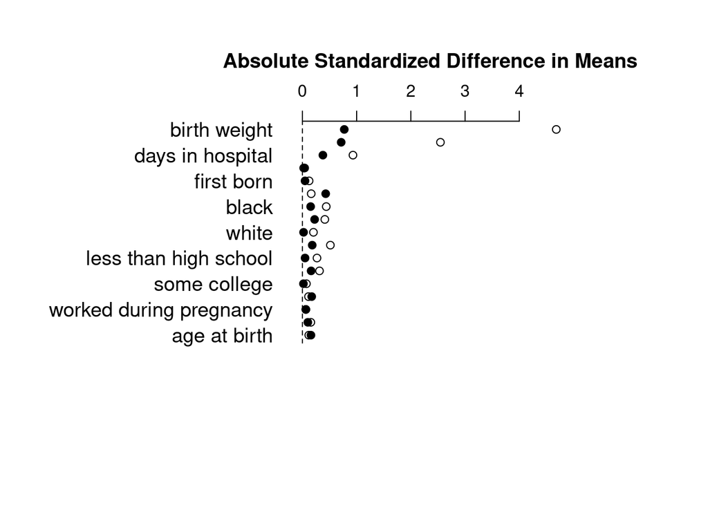

```r
pts <- bal_nr$diff.means.raw[,4]
pts2 <- bal_nr$diff.means.matched[,4]
K <- length(pts)
idx <- 1:K
main <- 'Absolute Standardized Difference in Means'

mar <- c(8, 6, 6, 7)
par(mar=mar)

maxchar <- max(sapply(cov_names, nchar))
min.mar <- par('mar')
mar[2] <- max(min.mar[2], trunc(mar[2] + maxchar/10)) + mar[2] + 0.5
par(mar=mar)

pts <- rev(pts)
pts2 <- rev(pts2)
longcovnames <- rev(cov_names)

plot(c(pts,pts2), c(idx,idx),
    bty='n', xlab='', ylab='',
    xaxt='n', yaxt='n', type='n',
    main=main, cex.main=1.2)
abline(v=0, lty=2)
points(pts, idx, cex=1)
points(pts2, idx, pch=19, cex=1)
axis(3)
axis(2, at=1:K, labels=longcovnames[1:K],
    las=2, hadj=1, lty=0, cex.axis=1.2)
```

#### Step 4: Diagnostics for balance and overlap

Separate balance plots for continuous and binary variables. Labelled cov names, ps_fit_1 MWR. Manual plot code based on the code in balance.R.

#### Figure

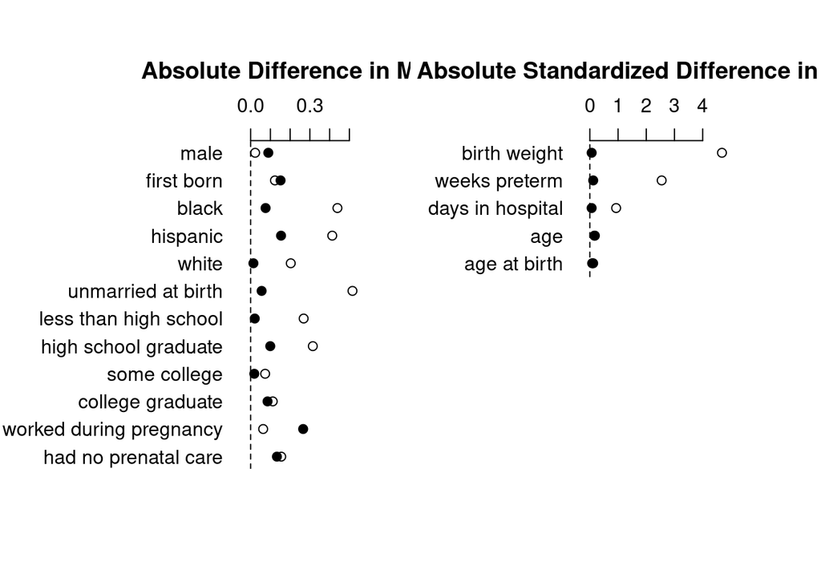

```r
par(mfrow=c(1,2))
mar1 <- c(5, 4, 6, 2)
mar2 <- c(5, 3, 6, 4)
pts <- bal_nr.wr$diff.means.raw[bal_nr.wr$binary==TRUE,4]
pts2 <- bal_nr.wr$diff.means.matched[bal_nr.wr$binary==TRUE,4]
K <- length(pts)
idx <- 1:K
main <- 'Absolute Difference in Means'
longcovnames <- cov_names[bal_nr.wr$binary==TRUE]

mar <- mar1
par(mar=mar)
maxchar <- max(sapply(longcovnames, nchar))
min.mar <- par('mar')
mar[2] <- max(min.mar[2], trunc(mar[2] + maxchar/10)) + mar[2] + 0.5
par(mar=mar)

pts <- rev(pts)
pts2 <- rev(pts2)
longcovnames <- rev(longcovnames)

plot(c(pts,pts2), c(idx,idx),
    bty='n', xlab='', ylab='',
    xaxt='n', yaxt='n', type='n',
    main=main, cex.main=1.2,
    xlim=c(0,.55))
abline(v=0, lty=2)
points(pts, idx, cex=1)
points(pts2, idx, pch=19, cex=1)
axis(3, at=seq(0,.5,.1), xpd=TRUE)
axis(2, at=1:K, labels=longcovnames[1:K],
    las=2, hadj=1, lty=0, cex.axis=1)
pts <- bal_nr.wr$diff.means.raw[bal_nr.wr$binary==FALSE,4]
pts2 <- bal_nr.wr$diff.means.matched[bal_nr.wr$binary==FALSE,4]
# AZC: hack to fix spacing of binary covariates against x axis
# the spacing of how spaced apart the ticks are changes as the number of covariates change. It's frustratingly hard, maybe impossible, to get the spacing to match between the continuous and binary plots with different number of covariates in each, so, I'll add fake data that won't show up
pts <- c(pts, rep(NA, 7))
pts2 <- c(pts2, rep(NA, 7))
K <- length(pts)
idx <- 1:K
main <- 'Absolute Standardized Difference in Means'
longcovnames <- cov_names[bal_nr.wr$binary==FALSE]
# add extra names to match above
longcovnames <- c(longcovnames, rep('', 7))

mar <- mar2
par(mar=mar)
maxchar <- max(sapply(longcovnames, nchar))
min.mar <- par('mar')
mar[2] <- max(min.mar[2], trunc(mar[2] + maxchar/10)) + mar[2] + 0.5
par(mar=mar)

pts <- rev(pts)
pts2 <- rev(pts2)
longcovnames <- rev(longcovnames)

plot(c(pts,pts2), c(idx,idx),
    bty='n', xlab='', ylab='',
    xaxt='n', yaxt='n', type='n',
    main=main, cex.main=1.2)
segments(x0=0, y0=13, x1=0, y1=7.5, lty=2)
points(pts, idx, cex=1)
points(pts2, idx, pch=19, cex=1)
axis(3)
axis(2, at=8:12, labels=longcovnames[8:12],
    las=2, hadj=1, lty=0, cex.axis=1)
```

#### Figure: Overlap of propensity scores before/after matching with replacement.

Pscores from original model.

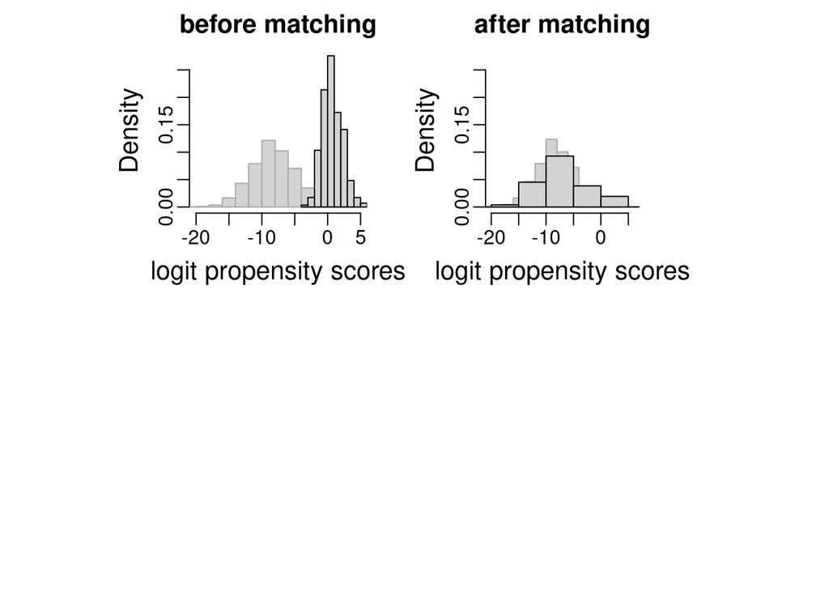

```r
par(mfrow=c(1,2), cex.main=1.3, cex.lab=1.3)
# Plot the overlapping histograms for pscores before matching, density
par(mar=c(16,8,2,2))
hist(pscores[cc2$treat==0], xlim=c(-20,5), ylim=c(0,.28), main="before matching", border="darkgrey", mgp=c(2,.5,0), xlab="logit propensity scores", freq=FALSE)
hist(pscores[cc2$treat==1], freq=FALSE, add=TRUE)
# Plot the overlapping histograms for pscores after matching, frequency
par(mar=c(16,3,2,8))
hist(pscores[cc2[matches.wr$match.ind, 'treat']==0], xlim=c(-20,6), ylim=c(0,.28), main="after matching", border="darkgrey", mgp=c(2,.5,0), xlab="logit propensity scores", freq=FALSE)
hist(pscores[cc2[matches.wr$match.ind, 'treat']==1], freq=FALSE, add=TRUE)
```

how many pscores[cc2$treat==0] left out of plot?

```r
sum(pscores[cc2$treat==0] < -20)
```

```
[1] 6
```

pscore matching check

```r
sum(pscores[cc2$treat==1] > max(pscores[cc2$treat==0]))
```

```
[1] 13
```

#### Figure: Example: good overlap, bad pscore.

```r
set.seed(20)
ps3.mod <- glm(treat ~ unemp.rt, data=cc2,family=binomial)
pscores3 <- predict(ps3.mod, type="link")
```

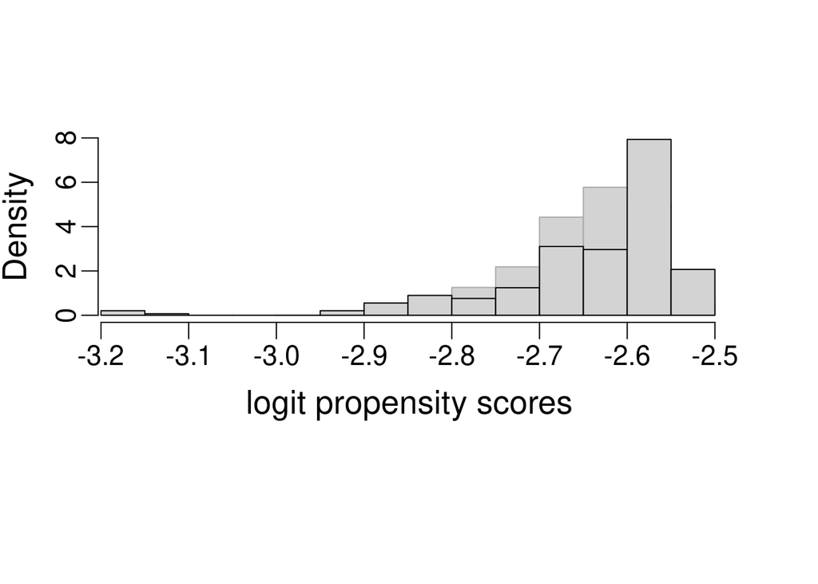

```r
par(mar=c(8,3,4,3), cex=1.4, cex.lab=1.2)
# Plot the overlapping histograms for pscore3, density
hist(pscores3[cc2$treat==0], xlim=range(pscores3), ylim=c(0,8),
     main="", border="darkgrey",
     mgp=c(2,.5,0), xlab="logit propensity scores",freq=FALSE)
hist(pscores3[cc2$treat==1], freq=FALSE, add=TRUE)
```

#### Step 5: Estimating a treatment effect using the restructured data.

```r
te_spec_nr <- update(ps_spec, ppvtr.36 ~ treat + .)
```

treatment effect without replacement

```r
set.seed(20)
reg_ps <- stan_glm(te_spec_nr, data=cc2[matches$match.ind,], algorithm='optimizing')
```

treatment effect with replacement

```r
set.seed(20)
reg_ps.wr <- stan_glm(te_spec_nr, data=cc2, weight=matches.wr$cnts, algorithm='optimizing')
ps_fit_1_design <- svydesign(ids=~1, weights=matches.wr$cnts, data=cc2)
reg_ps.wr_svy <- svyglm(te_spec_nr, design=ps_fit_1_design, data=cc2)

summary(reg_ps)['treat', 1:2]
```

```
   Median    MAD_SD
10.428777  1.518188
```

```r
summary(reg_ps.wr)['treat', 1:2]
```

```
   Median    MAD_SD
11.378185  1.230367
```

```r
summary(reg_ps.wr_svy)$coef['treat', 1:2]
```

```
  Estimate Std. Error
  9.699688   2.049842
```

Geographic information, covs_nr.st

```r
te_spec_nr.st <- update(ps_spec.st, ppvtr.36 ~ treat + . + st5 + st9 + st12 + st25 + st36 + st42 + st48 + st53)
```

treatment effect without replacement

```r
set.seed(20)
reg_ps.st <- stan_glm(te_spec_nr.st, data=cc2[matches.st$match.ind,], algorithm='optimizing')
```

treatment effect with replacement

```r
set.seed(20)
reg_ps.st.wr <- stan_glm(te_spec_nr.st, data=cc2, weight=matches.st.wr$cnts, algorithm='optimizing')
ps_fit_1.st_design <- svydesign(ids=~1, weights=matches.st.wr$cnts, data=cc2)
reg_ps.st.wr_svy <- svyglm(te_spec_nr.st, design=ps_fit_1.st_design, data=cc2)

summary(reg_ps.st)['treat', 1:2]
```

```
  Median   MAD_SD
7.795391 2.030057
```

```r
summary(reg_ps.st.wr)['treat', 1:2]
```

```
   Median    MAD_SD
11.360814  1.391956
```

```r
summary(reg_ps.st.wr_svy)$coef['treat', 1:2]
```

```
  Estimate Std. Error
  2.133385   2.570435
```

standard regression estimate of treatment effect

```r
set.seed(20)
reg_te <- stan_glm(te_spec_nr, data=cc2, algorithm='optimizing')
```

standard regression estimate of treatment effect with state

```r
set.seed(20)
reg_te.st <- stan_glm(te_spec_nr.st, data=cc2, algorithm='optimizing')

summary(reg_te)['treat', 1:2]
```

```
   Median    MAD_SD
11.378185  1.230367
```

```r
summary(reg_te.st)['treat', 1:2]
```

```
   Median    MAD_SD
11.360814  1.391956
```

## Improved pscore Model

Improved pscore model using an interaction or squared term.

transformed variables

```r
cc2$bwT = (cc2$bw-1500)^2
cc2$dayskidT = log(cc2$dayskidh+1)
cc2$pretermT = (cc2$preterm+8)^2
cc2$momageT = (cc2$momage^2)
```

New ps-spec from psFitR(21)

```r
ps_spec2 <- formula(treat ~ bwg*as.factor(educ) + as.factor(ethnic)*b.marr + work.dur + prenatal + preterm + momage + sex + first + bw + dayskidT + pretermT + momageT + black*(bw + preterm + dayskidT) + b.marr*(bw + preterm + dayskidT) + bw*income)
ps_spec_i21 <- formula(treat~bw+preterm+dayskidh+sex+hispanic+b.marr+lths+hs+ltcoll+work.dur+prenatal+momage+income+bwT+pretermT+income+black:dayskidT+b.marr:bw+b.marr:preterm+b.marr:dayskidT+bw:income)
ps_spec2 <- ps_spec_i21

set.seed(8)
ps_fit_2 <- stan_glm(ps_spec2, family=binomial(link="logit"), data=cc2, algorithm='optimizing')

pscores_2 <- apply(posterior_linpred(ps_fit_2, type='link'), 2, mean)
matches2 <- matching(z=cc2$treat, score=pscores_2, replace=FALSE)
matched2 <- cc2[matches2$match.ind,]
matches2_wr <- matching(z=cc2$treat, score=pscores_2, replace=TRUE)
matched2_wr <- cc2[matches2_wr$match.ind,]

bal_2 <- balance(rawdata=cc2[,covs], cc2$treat, matched=matches2$cnts, estimand='ATT')
```

```
Balance diagnostics assume that the estimand is the ATT
```

```r
bal_2.wr <- balance(rawdata=cc2[,covs], cc2$treat, matched=matches2_wr$cnts, estimand='ATT')
```

```
Balance diagnostics assume that the estimand is the ATT
```

look at some balance plots

```
4.68266 2.545888 0.9321339 0.162117 0.1177283
```

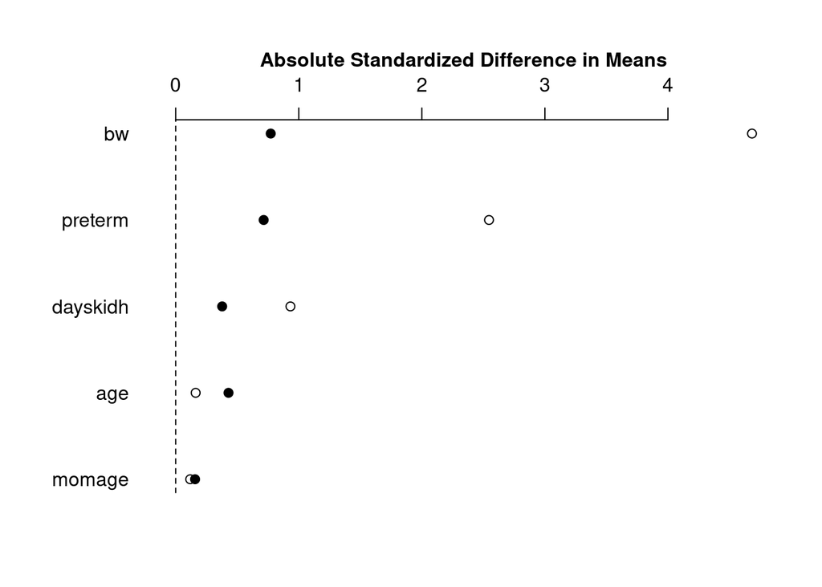

```
$raw
   momage       age  dayskidh   preterm        bw
0.1177283 0.1621170 0.9321339 2.5458881 4.6826604

$matched
   momage       age  dayskidh   preterm        bw
0.1573427 0.4290510 0.3774416 0.7148219 0.7720407
```

```r
par(mfrow=c(1,1))
plot.balance(bal_nr, which.covs='cont', main='ps_fit_1')
```

```
4.68266 2.545888 0.9321339 0.162117 0.1177283
```

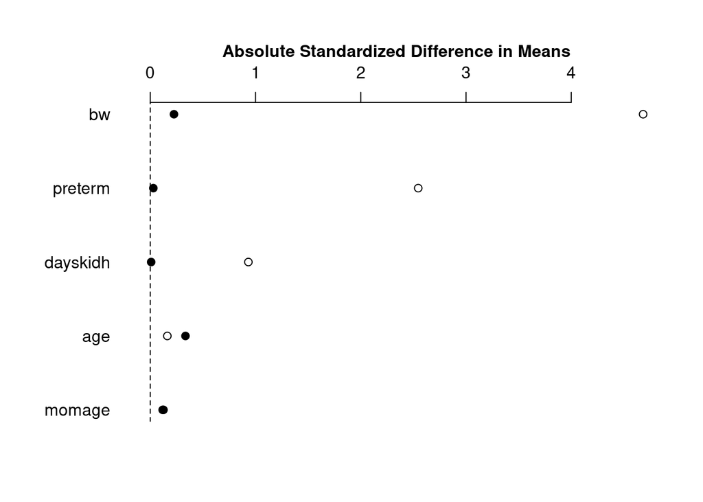

```
$raw
   momage       age  dayskidh   preterm        bw
0.1177283 0.1621170 0.9321339 2.5458881 4.6826604

$matched
     momage         age    dayskidh     preterm          bw
0.125639284 0.334463295 0.008587863 0.029032893 0.225210486
```

```r
plot.balance(bal_2.wr, which.covs='cont', main='ps_fit_2')
```

```
0.01141867 0.0615902 0.2201435 0.1202918 0.09985165 0.2558391 0.1333339 0.1420764 0.02734514 0.03608763 0.03121992 0.03211676
```

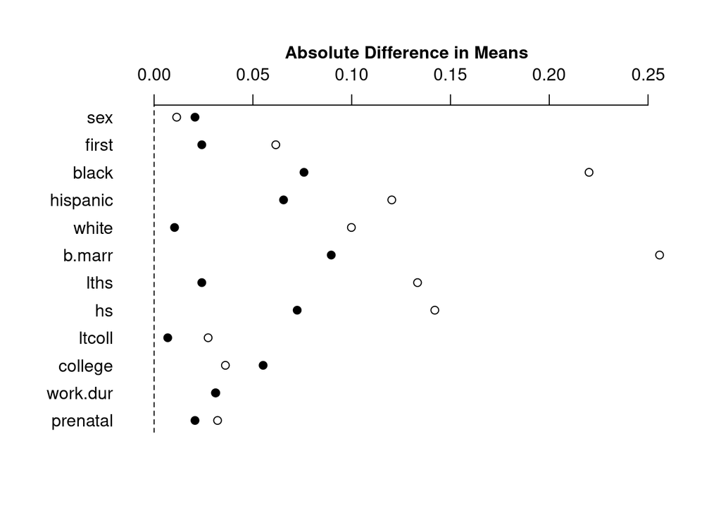

```
$raw
  prenatal   work.dur    college     ltcoll         hs       lths     b.marr
0.03211676 0.03121992 0.03608763 0.02734514 0.14207638 0.13333390 0.25583914
     white   hispanic      black      first        sex
0.09985165 0.12029181 0.22014346 0.06159020 0.01141867

$matched
   prenatal    work.dur     college      ltcoll          hs        lths
0.020689655 0.031034483 0.055172414 0.006896552 0.072413793 0.024137931
     b.marr       white    hispanic       black       first         sex
0.089655172 0.010344828 0.065517241 0.075862069 0.024137931 0.020689655
```

```r
plot.balance(bal_nr, which.covs='binary', main='ps_fit_1')
```

```
0.01141867 0.0615902 0.2201435 0.1202918 0.09985165 0.2558391 0.1333339 0.1420764 0.02734514 0.03608763 0.03121992 0.03211676
```

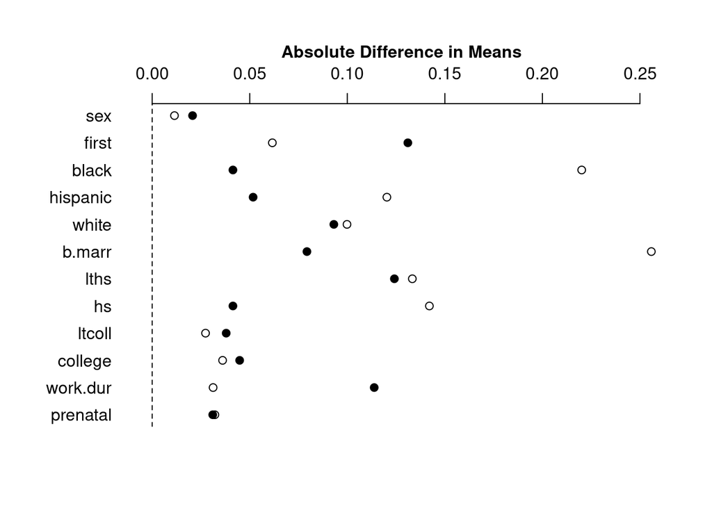

```
$raw
  prenatal   work.dur    college     ltcoll         hs       lths     b.marr
0.03211676 0.03121992 0.03608763 0.02734514 0.14207638 0.13333390 0.25583914
     white   hispanic      black      first        sex
0.09985165 0.12029181 0.22014346 0.06159020 0.01141867

$matched
  prenatal   work.dur    college     ltcoll         hs       lths     b.marr
0.03103448 0.11379310 0.04482759 0.03793103 0.04137931 0.12413793 0.07931034
     white   hispanic      black      first        sex
0.09310345 0.05172414 0.04137931 0.13103448 0.02068966
```

```r
plot.balance(bal_2.wr, which.covs='binary', main='ps_fit_2')
```

```
4.68266 2.545888 0.9321339 0.02280011 0.123041 0.162117 0.4395376 0.4132608 0.2031829 0.5157247 0.2685229 0.3149425 0.07345135 0.1119816 0.06335898 0.1549416 0.1177283
```

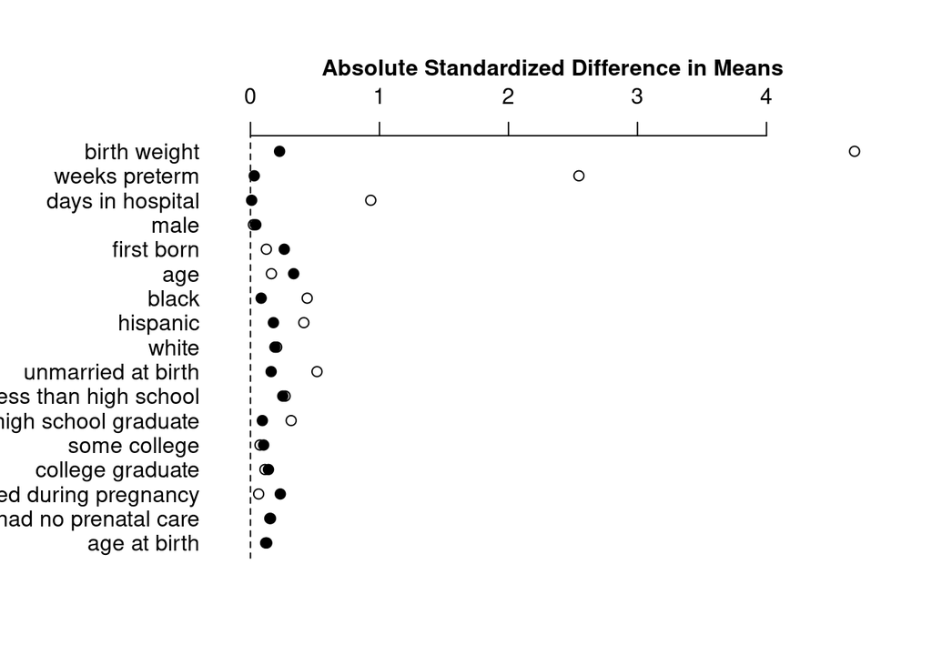

```
$raw
    momage   prenatal   work.dur    college     ltcoll         hs       lths
0.11772830 0.15494161 0.06335898 0.11198164 0.07345135 0.31494246 0.26852288
    b.marr      white   hispanic      black        age      first        sex
0.51572470 0.20318292 0.41326081 0.43953760 0.16211703 0.12304101 0.02280011
  dayskidh    preterm         bw
0.93213392 2.54588810 4.68266037

$matched
     momage    prenatal    work.dur     college      ltcoll          hs
0.125639284 0.149720363 0.230936365 0.139102147 0.101885952 0.091726025
       lths      b.marr       white    hispanic       black         age
0.250003004 0.159875082 0.189451350 0.177697544 0.082617775 0.334463295
      first         sex    dayskidh     preterm          bw
0.261772410 0.041311835 0.008587863 0.029032893 0.225210486
```

```r
plot.balance(bal_2.wr, longcovnames=cov_names)
```

#### Treatment effect

```r
te_spec2 <- formula(ppvtr.36 ~ treat + hispanic + black + b.marr + lths + hs + ltcoll + work.dur + prenatal + momage + sex + first + preterm + dayskidh + bw + income)
te_spec2 <- te_spec_nr
set.seed(8)
# MwoR
reg_ps2 <- stan_glm(te_spec2, data=matched2, algorithm='optimizing')
# MwR
reg_ps2.design <- svydesign(ids=~1, weights=matches2_wr$cnts, data=cc2)
reg_ps2.wr <- svyglm(te_spec2, design=reg_ps2.design, data=cc2)

summary(reg_ps2)['treat', 1:2]
```

```
   Median    MAD_SD
10.217023  1.707764
```

```r
summary(reg_ps2.wr)$coef['treat', 1:2]
```

```
  Estimate Std. Error
  8.219256   2.376333
```

#### Geographic information using ps_spec2

```r
ps_spec2.st <- update(ps_spec2, . ~ . + st5 + st9 + st12 + st25 + st36 + st42 + st48 + st53)

set.seed(8)
ps_fit_2.st <- stan_glm(ps_spec2.st, family=binomial(link='logit'), data=cc2, algorithm='optimizing')

pscores_2.st <- apply(posterior_linpred(ps_fit_2.st, type='link'), 2, mean)
matches2.st <- matching(z=cc2$treat, score=pscores_2.st, replace=FALSE)
matched2.st <- cc2[matches2.st$match.ind,]
matches2.st_wr <- matching(z=cc2$treat, score=pscores_2.st, replace=TRUE)
```

#### Treatment effect estimate

```r
te_spec2.st <- update(te_spec2, . ~ . + st5 + st9 + st12 + st25 + st36 + st42 + st48 + st53)
set.seed(8)
# MwoR
reg_ps2.st <- stan_glm(te_spec2.st, data=matched2.st, algorithm='optimizing')
reg_ps2.st_design <- svydesign(ids=~1, weights=matches2.st_wr$cnts, data=cc2)
reg_ps2.st.wr <- svyglm(te_spec2.st, design=reg_ps2.st_design, data=cc2)

summary(reg_ps2.st)['treat', 1:2]
```

```
  Median   MAD_SD
8.002963 2.114469
```

```r
summary(reg_ps2.st.wr)$coef['treat', 1:2]
```

```
  Estimate Std. Error
  7.564377   2.185574
```

```r
wt.iptw <- inv.logit(pscores) / (1 - inv.logit(pscores))
wt.iptw[cc2$treat==0] <- wt.iptw[cc2$treat==0] * (sum(wt.iptw[cc2$treat==0]) / sum(cc2$treat==0))
wt.iptw[cc2$treat==1] <- 1

set.seed(20)
ps_fit_iptw_design <- svydesign(ids=~1, weights=wt.iptw, data=cc2)
reg_ps.iptw <- svyglm(te_spec_nr, design=ps_fit_iptw_design, data=cc2)
summary(reg_ps.iptw)$coef['treat', 1:2]
```

```
  Estimate Std. Error
  8.358197   2.652154
```

## Beyond balance in means

```r
cont_vars <- c('bw', 'preterm', 'dayskidh', 'momage', 'income', 'age')
sds.um <- sapply(cont_vars, function(x){
    tapply(cc2[,x], cc2$treat, sd)
})
sds.mwor <- sapply(cont_vars, function(x){
    tapply(matched[,x], matched$treat, sd)
})
mwr.ind <- rep(cc2$row.names, times=matches.wr$cnts)
matched.wr <- cc2[mwr.ind, ]
sds.mwr <- sapply(cont_vars, function(x){
    tapply(matched.wr[,x], matched.wr$treat, sd)
})
```